# Umansky & Dumont (2021) Analysis & Replication

Anwesha Guha, Merly Klaas, & Thuy Nguyen

2/22/2022

```r
dat <- import(here("data","dumont_umansky_ECLSK.dta"))
```

### A. Baseline differences (3 points)

*For the following tasks, give your best attempt at completing the analysis. If you are unable to conduct the programming or analysis, describe what you are attempting to do and what your results would mean.*

**A1** Present graphical and/or numerical evidence on whether teachers perceive students who are classified as ELs as having weaker language and mathematics skills in this data set. Describe the results of your assessment in 3-4 sentences. Should the evidence you have shared here be interpreted as a plausibly causal estimate of the effect of being classified as an EL student on teachers’ perceptions of students’ ability? In 1-2 sentences, answer why or why not.

```r
perception_diff <- dat %>%
  group_by(elprgm) %>%
  summarise(n_students = n(),
            mean_math=mean(tmathk),
            se_math = sd(tmathk)/sqrt(n_students),
            mean_lang = mean(tlangk),
            se_lang = sd(tlangk)/sqrt(n_students))
```

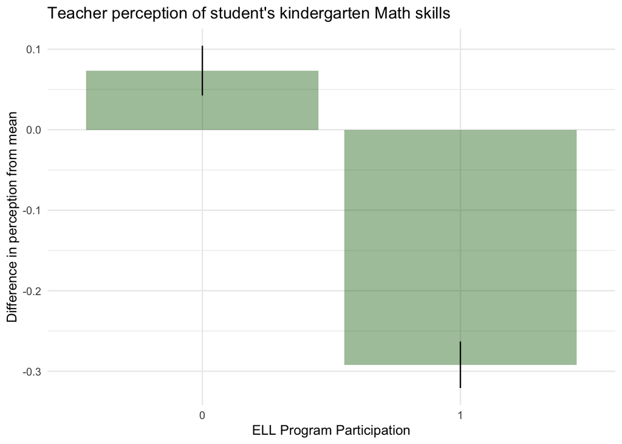

```r
ggplot(perception_diff,
       aes(x=as.factor(elprgm), y=mean_math, ymin=mean_math-se_math, ymax=mean_math+se_math)) +
  geom_col(fill = "darkgreen", alpha=0.4) +
  geom_linerange() +
  theme_pander(base_size = 16) +
  labs(x = "ELL Program Participation",
       y = "Difference in perception from mean",
       title = "Teacher perception of student's kindergarten Math skills") +
  theme_minimal()
```

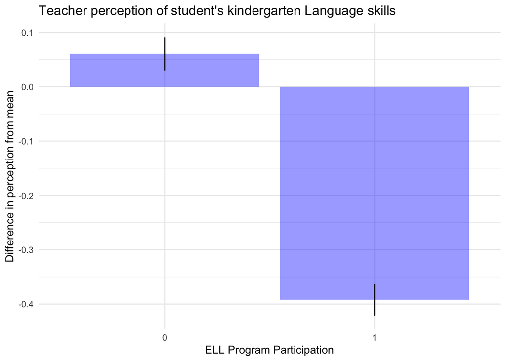

```r
ggplot(perception_diff,
       aes(x=as.factor(elprgm), y=mean_lang, ymin=mean_lang-se_lang, ymax=mean_lang+se_lang)) +
  geom_col(fill = "blue", alpha=0.4) +
  geom_linerange() +
  theme_pander(base_size = 16) +
  labs(x = "ELL Program Participation",
       y = "Difference in perception from mean",
       title = "Teacher perception of student's kindergarten Language skills") +
  theme_minimal()
```

```r
#Naive ols estimation of the effect of EL status on teacher perception of students academic skills
#language skills


ols_lang <- lm(tlangk ~ elprgm,
              data=dat)
summary(ols_lang)
```

```
##
## Call:
## lm(formula = tlangk ~ elprgm, data = dat)
##
## Residuals:
##      Min       1Q   Median       3Q      Max
## -2.93727 -0.69388  0.08948  0.76093  1.54429
##
## Coefficients:
##             Estimate Std. Error t value Pr(>|t|)
## (Intercept)  0.06071    0.03198   1.898   0.0578 .
## elprgm      -0.45285    0.04260 -10.631   <2e-16 ***
## ---
## Signif. codes:  0 '***' 0.001 '**' 0.01 '*' 0.05 '.' 0.1 ' ' 1
##
## Residual standard error: 0.9831 on 2164 degrees of freedom
## Multiple R-squared:  0.04964,    Adjusted R-squared:  0.0492
## F-statistic:   113 on 1 and 2164 DF,  p-value: < 2.2e-16
```

```r
#math skills
ols_math <- lm(tmathk ~ elprgm,
              data=dat)
summary(ols_math)
```

```
##
## Call:
## lm(formula = tmathk ~ elprgm, data = dat)
##
## Residuals:
##     Min      1Q  Median      3Q     Max
## -3.1583 -0.6542  0.1479  0.8135  1.4845
##
## Coefficients:
##             Estimate Std. Error t value Pr(>|t|)
## (Intercept)  0.07350    0.03203   2.295   0.0218 *
## elprgm      -0.36545    0.04266  -8.567   <2e-16 ***
## ---
## Signif. codes:  0 '***' 0.001 '**' 0.01 '*' 0.05 '.' 0.1 ' ' 1
##
## Residual standard error: 0.9845 on 2164 degrees of freedom
## Multiple R-squared:  0.03281,    Adjusted R-squared:  0.03236
## F-statistic:  73.4 on 1 and 2164 DF,  p-value: < 2.2e-16
```

For both language and math skills, teachers perceived multilingual students who participate in the ELL program as having lower ability. However, this should not be interpreted as causal; the causal inference assumptions are not met.

**A2** Are there other ways in which students classified as EL learners are different from other students who live in homes where a language other than English is predominantly spoken, but are not classified as ELs? Present a table with quantitative information summarizing this fact and describe how this motivates your analytic strategy in Section B in 3-4 sentences.

```r
table_diff <- tableby(elprgm ~ hisp + ses + chrabsk + kexecfunc1 + female + rural + ebrs + prelas,
                 numeric.stats= c("meansd"), cat.stats=c("N", "countpct"), digits=2, data=dat)

summary(table_diff)
```

|  | 0 (N=945) | 1 (N=1221) | Total (N=2166) | p value |
| --- | --- | --- | --- | --- |
| **hisp** |  |  |  | < 0.001 |
| Mean (SD) | 0.50 (0.50) | 0.75 (0.44) | 0.64 (0.48) |  |
| **continuous measure of student’s socioeconomic status** |  |  |  | < 0.001 |
| Mean (SD) | -0.21 (0.91) | -0.69 (0.68) | -0.48 (0.82) |  |
| **student chronically absent in kinder** |  |  |  | 0.025 |
| Mean (SD) | 0.13 (0.33) | 0.10 (0.30) | 0.11 (0.31) |  |
| **student’s kinder executive functioning score 1: card sort** |  |  |  | < 0.001 |
| Mean (SD) | 14.17 (3.26) | 12.97 (3.89) | 13.49 (3.68) |  |
| **student is female** |  |  |  | 0.396 |
| Mean (SD) | 0.51 (0.50) | 0.49 (0.50) | 0.50 (0.50) |  |
| **student attends school in a rural area** |  |  |  | < 0.001 |
| Mean (SD) | 0.14 (0.34) | 0.08 (0.27) | 0.11 (0.31) |  |
| **student’s total EBRS score** |  |  |  | < 0.001 |
| Mean (SD) | 13.41 (4.57) | 10.79 (4.72) | 11.94 (4.83) |  |
| **student’s total PreLAS score** |  |  |  | < 0.001 |
| Mean (SD) | 17.62 (3.32) | 14.55 (4.89) | 15.89 (4.54) |  |

### B. Replication and Extension (7 points)

*For the following tasks, give your best attempt at completing the analysis. If you are unable to conduct the programming or analysis, describe what you are attempting to do and what your results would mean.*

**B1.** Develop a formal model (an equation) that describes the probability that a student who lives in a home where a language other than English is predominantly spoken will be identified as an EL. Start with a basic model that defines EL-classification as a function of PreLAS score, EBRS score, SES, Rurality, Gender and Ethnicity (Hispanic/Latinx or not). From this starting probability, present a visual describing the region of common support for EL- and non-EL-classified students. Describe the substantive implications to your analytic strategy of this figure in 2-3 sentences.

For our analysis, we will use the following model:

$$elprgm = PreLAS + EBRS + kexecfunc1 + SES + rural + female + hisp$$

where $elprgm$ is student participation in the EL program, $PreLAS$ and $EBRS$ are student’s total scores from those two tests, $kexecfunc1$ is kindergarten executive function score, $rural$ is student attending school in a rural area, $female$ is student identifying as female, and $hisp$ is student identifying as Hispanic/Latinx.

```r
# 1. Fit logistic selection model estimating probability of participating in program, given covariates
pscores <- feglm(elprgm ~ prelas + ebrs + ses + kexecfunc1 + rural + female + hisp, family=c("logit"), data=dat)
summary(pscores)
```

```
## GLM estimation, family = binomial(link = "logit"), Dep. Var.: elprgm
## Observations: 2,166
## Standard-errors: IID
##              Estimate Std. Error   t value   Pr(>|t|)
## (Intercept)  3.046762   0.320047  9.519736  < 2.2e-16 ***
## prelas      -0.147814   0.016233 -9.105686  < 2.2e-16 ***
## ebrs        -0.024275   0.012284 -1.976174 4.8135e-02 *
## ses         -0.379779   0.071417 -5.317766 1.0505e-07 ***
## kexecfunc1  -0.027185   0.014318 -1.898632 5.7613e-02 .
## rural       -0.614306   0.156862 -3.916217 8.9949e-05 ***
## female      -0.054920   0.095492 -0.575125 5.6521e-01
## hisp         0.337650   0.114721  2.943230 3.2481e-03 **
## ---
## Signif. codes:  0 '***' 0.001 '**' 0.01 '*' 0.05 '.' 0.1 ' ' 1
## Log-Likelihood: -1,284.4   Adj. Pseudo R2: 0.129599
##            BIC:  2,630.3     Squared Cor.: 0.182884
```

```r
# 2. Estimate fitted probability of selection into treatment for each individual
pscore_df <- data.frame(p_score = predict(pscores, type = "response"),
                        elprgm = dat$elprgm)
head(pscore_df)
```

```
##     p_score elprgm
## 1 0.7484722      1
## 2 0.3117790      0
## 3 0.4185726      0
## 4 0.6425941      0
## 5 0.7599968      1
## 6 0.4264998      1
```

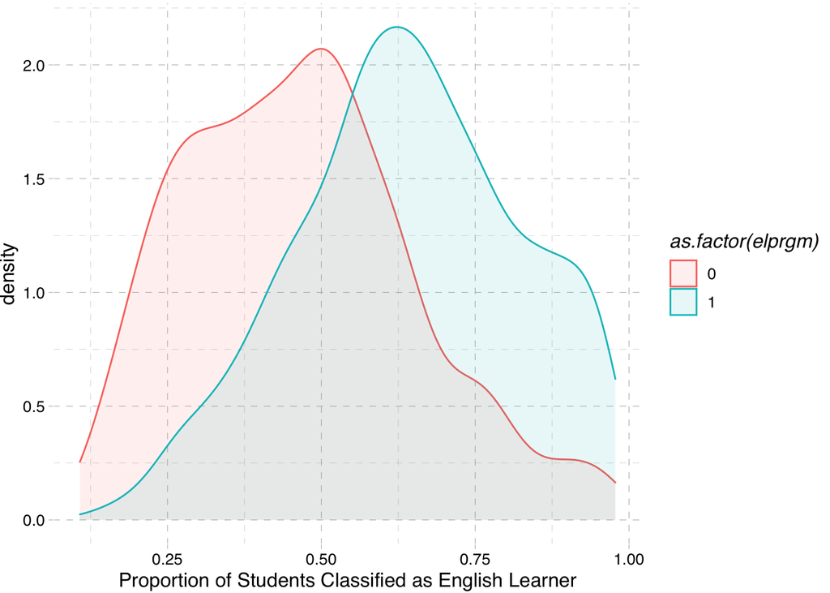

```r
# 3. Examine common support
ggplot(pscore_df, aes(p_score,fill = as.factor(elprgm), color = as.factor(elprgm))) +
  geom_density(alpha=0.1) +
  theme_pander(base_size = 12) +
  xlab("Proportion of Students Classified as English Learner")
```

Before matching, the figure above shows the region of common support. However, the two samples (participating in the EL program or not) are different on other characteristics as explained earlier, so we will try to increase the region of common support by matching below.

```r
# 1. Generate matches
matched <- matchit(elprgm ~ prelas + ebrs + kexecfunc1 + ses + rural + female + hisp, method="nearest", replace=T,
                   discard="both", data=dat)

# Create dataframe from matched data
df_match <- match.data(matched)

# Dimensions of dataframe
dim(df_match) #compared to 2166 x 16
```

```
## [1] 1689   18
```

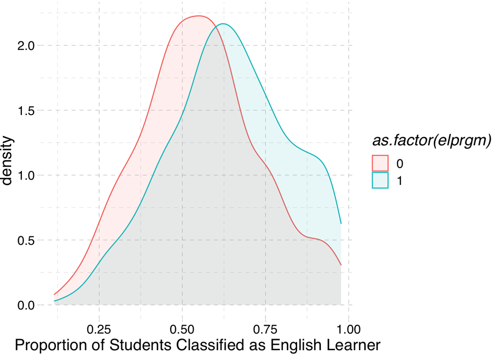

```r
## 2. Examine common support (post-match)
ggplot(df_match, aes(distance,fill = as.factor(elprgm), color = as.factor(elprgm))) +
        geom_density(alpha=0.1) +
        theme_pander(base_size = 16) +
        xlab("Proportion of Students Classified as English Learner")
```

```r
## 3. Examine quality of matches, descriptively
summary(matched) # see slide 29 to interpret quality of matches
```

```
##
## Call:
## matchit(formula = elprgm ~ prelas + ebrs + kexecfunc1 + ses +
##     rural + female + hisp, data = dat, method = "nearest", discard = "both",
##     replace = T)
##
## Summary of Balance for All Data:
##            Means Treated Means Control Std. Mean Diff. Var. Ratio eCDF Mean
## distance          0.6401        0.4650          0.9628     0.9571    0.2521
## prelas           14.5479       17.6201         -0.6277     2.1724    0.1463
## ebrs             10.7944       13.4127         -0.5541     1.0710    0.1247
## kexecfunc1       12.9689       14.1704         -0.3086     1.4280    0.0667
## ses              -0.6864       -0.2113         -0.6945     0.5679    0.1306
## rural             0.0811        0.1376         -0.2069          .    0.0565
## female            0.4906        0.5090         -0.0368          .    0.0184
## hisp              0.7461        0.5005          0.5642          .    0.2456
##            eCDF Max
## distance     0.4057
## prelas       0.3523
## ebrs         0.2395
## kexecfunc1   0.1194
## ses          0.2612
## rural        0.0565
## female       0.0184
## hisp         0.2456
##
##
## Summary of Balance for Matched Data:
##            Means Treated Means Control Std. Mean Diff. Var. Ratio eCDF Mean
## distance          0.6401        0.6401         -0.0000     0.9969    0.0011
## prelas           14.5479       14.7740         -0.0462     0.9619    0.0188
## ebrs             10.7944       11.0524         -0.0546     0.9639    0.0131
## kexecfunc1       12.9689       12.6749          0.0755     0.9678    0.0178
## ses              -0.6864       -0.7216          0.0514     1.0803    0.0116
## rural             0.0811        0.0590          0.0810          .    0.0221
## female            0.4906        0.4742          0.0328          .    0.0164
## hisp              0.7461        0.7576         -0.0263          .    0.0115
##            eCDF Max Std. Pair Dist.
## distance     0.0131          0.0040
## prelas       0.0541          0.3414
```

[output cut: 10 more lines]

```
## prelas                92.6       95.0      87.2     84.7
## ebrs                  90.1       46.5      89.5     83.2
## kexecfunc1            75.5       90.8      73.3     49.9
## ses                   92.6       86.4      91.1     87.5
## rural                 60.9          .      60.9     60.9
## female                11.0          .      11.0     11.0
## hisp                  95.3          .      95.3     95.3
##
## Sample Sizes:
##               Control Treated
## All            945.      1221
## Matched (ESS)  255.68    1221
## Matched        468.      1221
## Unmatched      473.         0
## Discarded        4.         0
```

In the summary of balance, we see that the standard mean difference decreases for the the matched data.

```r
#Estimate of EL status on Teacher perception of students' language skills using nearest neighbor matching
psmatch_lang <- lm(tlangk ~ elprgm + prelas + ebrs + kexecfunc1+ ses+ rural + female + hisp,
              data=df_match,
              weights=weights)

#Estimate of EL status on Teacher perception of students' math skills using nearest neighbor matching

psmatch_math <- lm(tmathk ~ elprgm + prelas + ebrs + kexecfunc1 + ses + rural + female + hisp,
              data=df_match,
              weights=weights)


summary(psmatch_lang)
```

```
##
## Call:
## lm(formula = tlangk ~ elprgm + prelas + ebrs + kexecfunc1 + ses +
##     rural + female + hisp, data = df_match, weights = weights)
##
## Weighted Residuals:
##     Min      1Q  Median      3Q     Max
## -3.1387 -0.5438  0.0588  0.5985  3.1642
##
## Coefficients:
##              Estimate Std. Error t value Pr(>|t|)
## (Intercept) -2.144357   0.113218 -18.940  < 2e-16 ***
## elprgm      -0.065489   0.047400  -1.382  0.16727
## prelas      -0.001142   0.005118  -0.223  0.82338
## ebrs         0.105994   0.005390  19.664  < 2e-16 ***
## kexecfunc1   0.030730   0.005707   5.385 8.29e-08 ***
## ses          0.036266   0.036312   0.999  0.31807
## rural       -0.069051   0.080697  -0.856  0.39230
## female       0.138029   0.042521   3.246  0.00119 **
## hisp         0.340997   0.056489   6.036 1.93e-09 ***
## ---
## Signif. codes:  0 '***' 0.001 '**' 0.01 '*' 0.05 '.' 0.1 ' ' 1
##
## Residual standard error: 0.8695 on 1680 degrees of freedom
## Multiple R-squared:  0.2803, Adjusted R-squared:  0.2768
## F-statistic: 81.77 on 8 and 1680 DF,  p-value: < 2.2e-16
```

```r
summary(psmatch_math)
```

```
##
## Call:
## lm(formula = tmathk ~ elprgm + prelas + ebrs + kexecfunc1 + ses +
##     rural + female + hisp, data = df_match, weights = weights)
##
## Weighted Residuals:
##     Min      1Q  Median      3Q     Max
## -3.6069 -0.5671  0.0797  0.6850  3.1753
##
## Coefficients:
##              Estimate Std. Error t value Pr(>|t|)
## (Intercept) -1.568497   0.122358 -12.819  < 2e-16 ***
## elprgm      -0.035946   0.051226  -0.702 0.482949
## prelas      -0.005660   0.005531  -1.023 0.306324
## ebrs         0.082367   0.005825  14.139  < 2e-16 ***
## kexecfunc1   0.023865   0.006168   3.869 0.000113 ***
## ses          0.047197   0.039243   1.203 0.229267
## rural       -0.043448   0.087212  -0.498 0.618418
## female       0.092594   0.045954   2.015 0.044069 *
## hisp         0.250247   0.061049   4.099 4.35e-05 ***
## ---
## Signif. codes:  0 '***' 0.001 '**' 0.01 '*' 0.05 '.' 0.1 ' ' 1
##
## Residual standard error: 0.9397 on 1680 degrees of freedom
## Multiple R-squared:  0.1612, Adjusted R-squared:  0.1572
## F-statistic: 40.37 on 8 and 1680 DF,  p-value: < 2.2e-16
```

```r
# Estimate confidence intervals
confint(psmatch_lang)
```

```
##                   2.5 %       97.5 %
## (Intercept) -2.36642140 -1.922293300
## elprgm      -0.15845805  0.027479243
## prelas      -0.01118048  0.008895551
## ebrs         0.09542163  0.116566254
## kexecfunc1   0.01953630  0.041923874
## ses         -0.03495529  0.107486487
## rural       -0.22732915  0.089227228
## female       0.05462894  0.221428522
## hisp         0.23020050  0.451794172
```

```r
confint(psmatch_math)
```

```
##                    2.5 %       97.5 %
## (Intercept) -1.808487390 -1.328507429
## elprgm      -0.136419960  0.064526966
## prelas      -0.016508049  0.005188601
## ebrs         0.070941692  0.093793201
## kexecfunc1   0.011767369  0.035962163
## ses         -0.029773186  0.124167088
## rural       -0.214502692  0.127607431
## female       0.002461917  0.182726254
## hisp         0.130506432  0.369988069
```

In a matched sample of students who had nearly identical language proficiency scores, executive functioning score, rurality, Gender and Ethnicity (Hispanic/Latinx or not) and were equally likely to be labelled as EL on these observable conditions, the effect of being classified as EL to **decrease** teacher perception of student’s language skills scores by 0.065 scale score points [95% CI: -0.16, 0.03] and to **decrease** teacher perception of student’s math skills scores by 0.035 scale score points [95% CI: -0.13, 0.06]. However, both of these effects are **not statistically significant**. To the extent that students’ classification as English Learner is based entirely on these characteristics, we can interpret this a credibly causal estimate of the effect of EL status on teacher perception of students’ academic skills among Multilingual Students, purged of observable variable bias.

**B2.** Construct a Coarsened Exact Matching (CEM) algorithm similar to Umansky and Dumont (see Class 8 Lecture) that relies on the following matching variables: (1) prelas, (2) ebrs, (3) ses, (4) rural, (5) female and (6) hisp. Variables 1-3 are continuous. You should decide whether you will follow Umansky and Dumont’s choices for cutpoints or select other reasonable cutpoint values. Variables 4-6 are dichomotous and you should insist on exact matches for these categories. Write 1-2 paragraphs describing the identification strategy (remember this is different from your estimation strategy), its accompanying assumptions, your matching procedures and the resulting number of excluded sample members.

```r
#Coarsened Exact Matching
#Step 1. Define coarsened bins of covariates within which to match
# Create coarsened forPreLAS variable
prelas_quints <- quantcut(dat$prelas, 5)
table(prelas_quints)
```

```
## prelas_quints
##  [0,13] (13,16] (16,18] (18,20)      20
##     455     440     552     251     468
```

```r
#Create coarsened for EBRS
ebrs_quints <- quantcut(dat$ebrs, 5)
table(ebrs_quints)
```

```
## ebrs_quints
##   [0,7]  (7,11] (11,14] (14,17] (17,20]
##     471     465     435     526     269
```

```r
#Create bins for kexecfunc1 - median 15
summary(dat$kexecfunc1)
```

```
##    Min. 1st Qu.  Median    Mean 3rd Qu.    Max.
##    0.00   13.00   15.00   13.49   16.00   18.00
```

```r
#Create coarsened for SES
ses_quints <- quantcut(dat$ses, 5)
table(ses_quints)
```

```
## ses_quints
## [-2.33,-1.12] (-1.12,-0.84] (-0.84,-0.52]  (-0.52,0.14]   (0.14,2.44]
##           438           429           435           431           433
```

```r
cem <- matchit(elprgm ~ prelas_quints + ebrs_quints + ses_quints + kexecfunc1 + rural + female + hisp,
               cutpoints = list(kexecfunc1 = 15),
               method="cem",
               data=dat)

# Create dataframe from matched data
df_cem <- match.data(cem)
# Dimensions of dataframe
dim(df_cem)
```

```
## [1] 829  18
```

```r
table(df_cem$elprgm)
```

```
##
##   0   1
## 373 456
```

```r
summary(cem)
```

```
##
## Call:
## matchit(formula = elprgm ~ prelas_quints + ebrs_quints + ses_quints +
##     kexecfunc1 + rural + female + hisp, data = dat, method = "cem",
##     cutpoints = list(kexecfunc1 = 15))
##
## Summary of Balance for All Data:
##                         Means Treated Means Control Std. Mean Diff. Var. Ratio
## prelas_quints[0,13]            0.3071        0.0847          0.4823          .
## prelas_quints(13,16]           0.2555        0.1354          0.2753          .
## prelas_quints(16,18]           0.2383        0.2762         -0.0889          .
## prelas_quints(18,20)           0.0876        0.1524         -0.2290          .
## prelas_quints20                0.1114        0.3513         -0.7627          .
## ebrs_quints[0,7]               0.2752        0.1429          0.2963          .
## ebrs_quints(7,11]              0.2596        0.1566          0.2350          .
## ebrs_quints(11,14]             0.2007        0.2011         -0.0010          .
## ebrs_quints(14,17]             0.1974        0.3016         -0.2618          .
## ebrs_quints(17,20]             0.0672        0.1979         -0.5223          .
## ses_quints[-2.33,-1.12]        0.2514        0.1386          0.2600          .
## ses_quints(-1.12,-0.84]        0.2432        0.1397          0.2414          .
## ses_quints(-0.84,-0.52]        0.2170        0.1799          0.0901          .
## ses_quints(-0.52,0.14]         0.1777        0.2265         -0.1275          .
## ses_quints(0.14,2.44]          0.1106        0.3153         -0.6530          .
## kexecfunc1                    12.9689       14.1704         -0.3086      1.428
## rural                          0.0811        0.1376         -0.2069          .
## female                         0.4906        0.5090         -0.0368          .
## hisp                           0.7461        0.5005          0.5642          .
##                         eCDF Mean eCDF Max
## prelas_quints[0,13]        0.2225   0.2225
## prelas_quints(13,16]       0.1201   0.1201
## prelas_quints(16,18]       0.0379   0.0379
## prelas_quints(18,20)       0.0647   0.0647
## prelas_quints20            0.2399   0.2399
## ebrs_quints[0,7]           0.1323   0.1323
## ebrs_quints(7,11]          0.1030   0.1030
## ebrs_quints(11,14]         0.0004   0.0004
## ebrs_quints(14,17]         0.1042   0.1042
## ebrs_quints(17,20]         0.1307   0.1307
## ses_quints[-2.33,-1.12]    0.1128   0.1128
## ses_quints(-1.12,-0.84]    0.1036   0.1036
```

[output cut: 65 more lines]

```
## ses_quints(-0.84,-0.52]           100.0          .     100.0    100.0
## ses_quints(-0.52,0.14]            100.0          .     100.0    100.0
## ses_quints(0.14,2.44]             100.0          .     100.0    100.0
## kexecfunc1                         99.2         94      97.7     86.3
## rural                             100.0          .     100.0    100.0
## female                            100.0          .     100.0    100.0
## hisp                              100.0          .     100.0    100.0
##
## Sample Sizes:
##               Control Treated
## All            945.      1221
## Matched (ESS)  175.69     456
## Matched        373.       456
## Unmatched      572.       765
## Discarded        0.         0
```

In this analysis, we decided to utilize Coarsened exact matching (CEM) strategy to reduce observed variable bias by removing from the sample and subsequent estimation any individuals in EL group who cannot be matched with individuals in the non EL group. Further, for each observed variable, we chose number of bins based on prior knowledge about our data and match our sample within each bin. Following Umansky and Dumont’s strategy, we binned PreLAS, EBRS and SES into quintiles, executive function score into halves, and forced exact match for rurality, gender and ethnicity (Hispanic or Not). Matching by quintiles has been shown to eliminate more than 90% of bias (Umansky & Dumont, 2021). Using this CEM procedure, we lost 572 sample from non EL group and 765 sample from EL group. In total, we excluded 1337 sample from our pre-matched dataset.

**B3.** Assess the quality of your matches by looking at the region of common support in your newly matched sample. Assess the quality of your matches by comparing baseline variable values in the treated and non- treated conditions. Provide a summary assessment of the quality of your matches, the extent to which you have accomplished balance, and the impact your matching has had on your sample as it relates to both variance and generalizability. Do you think you should try different matching criteria to achieve a better result? Why or why not (it is not necessary at this point to actually conduct multiple re-matching procedures, just assess whether they would be valuable)?

```r
cemresult <- summary(cem)

df_cem_result <- data.frame(unlist(round(cemresult[[4]],3)))[,1:3]

table_cem <- df_cem_result %>%
tibble::rownames_to_column("Variable") %>%
  rename("Means Treated" = Means.Treated,
         "Means Control"= Means.Control,
         "Std.Mean Diff" = Std..Mean.Diff.)
table_cem
```

```
##                   Variable Means Treated Means Control Std.Mean Diff
## 1      prelas_quints[0,13]         0.296         0.296         0.000
## 2     prelas_quints(13,16]         0.175         0.175         0.000
## 3     prelas_quints(16,18]         0.303         0.303         0.000
## 4     prelas_quints(18,20)         0.068         0.068         0.000
## 5          prelas_quints20         0.158         0.158         0.000
## 6         ebrs_quints[0,7]         0.283         0.283         0.000
## 7        ebrs_quints(7,11]         0.235         0.235         0.000
## 8       ebrs_quints(11,14]         0.154         0.154         0.000
## 9       ebrs_quints(14,17]         0.254         0.254         0.000
## 10      ebrs_quints(17,20]         0.075         0.075         0.000
## 11 ses_quints[-2.33,-1.12]         0.294         0.294         0.000
## 12 ses_quints(-1.12,-0.84]         0.193         0.193         0.000
## 13 ses_quints(-0.84,-0.52]         0.219         0.219         0.000
## 14  ses_quints(-0.52,0.14]         0.158         0.158         0.000
## 15   ses_quints(0.14,2.44]         0.136         0.136         0.000
## 16              kexecfunc1        13.482        13.492        -0.003
## 17                   rural         0.013         0.013         0.000
## 18                  female         0.489         0.489         0.000
## 19                    hisp         0.768         0.768         0.000
```

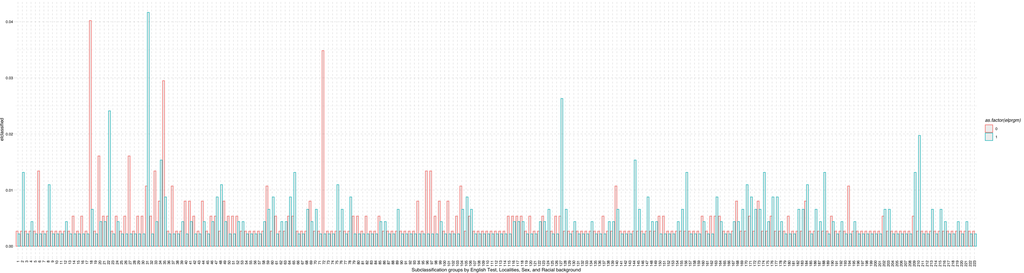

```r
# Plot common support
df_cem2 <- df_cem %>% group_by(elprgm, subclass) %>%
              summarise(count= n())
df_cem2 <- df_cem2 %>%  mutate(elclassified = count / sum(count))

# Examine quality of matches for each variable grouping
p <- ggplot(df_cem2, aes(subclass,elclassified, color = as.factor(elprgm))) +
          geom_col(alpha=0.1, position = position_dodge()) +
          theme_pander(base_size = 10) +
          xlab("Subclassification groups by English Test, Localities, Sex, and Racial background")+
  theme(axis.text.x = element_text(angle = 90, vjust = 0.5, hjust=1))
p
```

```r
#ggsave("p.pdf", width = 30, height = 8, units= "in")
```

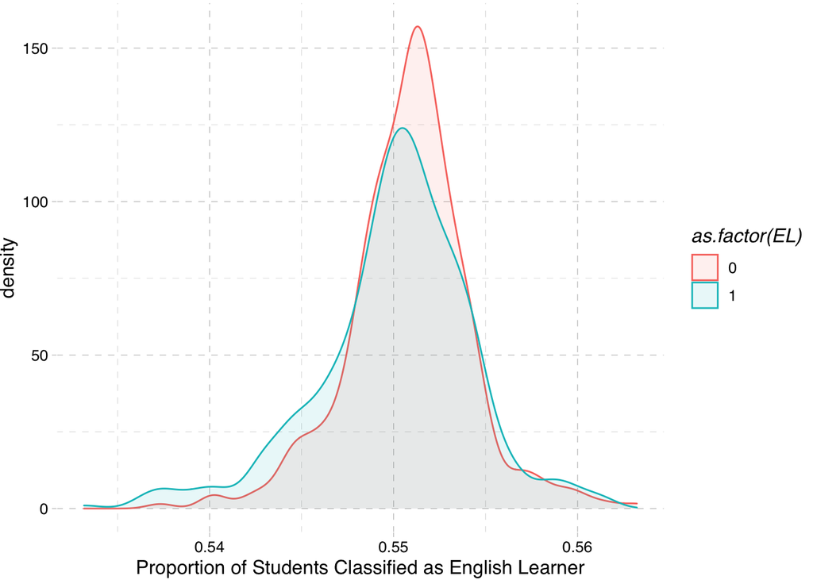

```r
pscores2 <- feglm(elprgm ~ prelas + ebrs + kexecfunc1 + ses + rural + female + hisp,
family=c("logit"),
weights = df_cem$weights,
data=df_cem)

df2 <- data.frame(p_scores=predict(pscores2, type="response"),
EL = df_cem$elprgm)

ggplot(df2, aes(p_scores,fill = as.factor(EL), color = as.factor(EL))) +
  geom_density(alpha=0.1) +
  theme_pander(base_size = 12) +
  xlab("Proportion of Students Classified as English Learner")
```

If we have better idea about the empirical cutoff points of SES, preLas, and ebrs for the US students at this age, we could try using that instead of using quintiles points to match. This could benefit us in terms of substantive meaning.

**B4.** Using your newly matched sample, estimate the average treatment effect of EL classification on teachers’ perceptions of students’ math and language ability in your newly matched sample. If you decide to do B5, present these results and associated discussion along with the rest of your results in B5. If you do not, answer the rest of the prompt with just the CEM results. Present your CEM results and compare them to your results in A1 in a table and an accompanying write-up as you would report these in an academic paper in 1-2 paragraphs.

Comparison of OLS, PSM and CEM estimates of Effect of EL Status on Teacher Perceptions of Students’ Academic Skills, Among Multilingual Students

OLS

OLS

PSM

PSM

CEM

CEM

Language

Math

Language

Math

Language

Math

EL status

−0.453***

−0.365***

−0.065

−0.036

−0.101

−0.087

(0.043)

(0.043)

(0.047)

(0.051)

(0.058)

(0.062)

Num.Obs.

2166

2166

1689

1689

829

829

* p < 0.05, ** p < 0.01, *** p < 0.001

*Table 2 footnotes* *Model 3-6 match on English proficiency & Executive functioning score, SES, Rurality, Gender, and Ethnicity. Model 5-6 use narrower bins. The english proficiency variables were matched by sample distribution quantile while the executive functioning measure was matched by sample distribution halves. All CEM and PSM estimates are double-robust.*

**B5.** (OPTIONAL) Conduct a robustness check by estimating the causal effect of EL classification on teacher perceptions of student skills by using a propensity score matching approach (or another approach from the matching family if you choose). Share information on the quality of these matches and any additional assumptions associated with this approach. Present these results alongside your results in B4 in an accompanying table(s) and write-up as you would report these in an academic paper in 2-3 paragraphs.

**We use Propensity Score Matching (nearest neighbor) estimation in our analysis and present the results in table 2**

**B6.** Write a discussion paragraph in which you present the substantive conclusions (and limitations) of your results about the effects of EL classification on teacher perception of student skills in Kindergarten.

A naive estimate for both language and math skills suggest that kindergarten teachers perceive multilingual students who participate in the ELL program as having lower ability than students who do not participate in the EL program. However, the characteristics of students from either group were substantially different from each other, so a causal interpretation would be inappropriate. Specifically, in the EL group for example, there are higher proportion Hispanic/Latinx, come from lower socioeconomic status, and go to less rural schools.

We theorize that the primary driver of teacher perception of language and math skills is EL program participation. Conditional on this characteristic (in addition to test scores and demographic information), we implement two separate matching algorithms: Propensity Score Matching and Coarsened Exact Matching. Both sets of estimates indicate that the two populations are not significantly different from each other in regards to teacher perception. Thus, as the result of using narrower bins, we considered small sample size as the limitation of this analysis.